# rmarkdown

Luoyan Yong

27/04/2021

## What is markdown?

### Text formatting

1. Headers Header 1 - #

Header 2 - ##

Header 3 - ###

Header 4 - ####

2. Lists Bullet points can be added with -
- item 1
- item 2
- item 3
3. Tables + text formats

[output not shown]

4. Embed images and links

[google image](https://www.image.google.com)

[figure not shown]

embl logo

[figure not shown]

rmd workfllow

## Code chunk

1. How to add code chunks?
- Code> Insert Chunk
- shortcut with cmd + opt + I
- manually typing `{r} and`

### chunk Names

- better organise your code and easier navigation
- graphics will have useful name; chunk label is used to generate the file name of the graphic on disk
- special name “setup” to specify default options

### Chunk options

```r
library(tidyverse)
```

```r
library(dplyr)

ggplot(mtcars, aes(x = mpg, y = wt)) +
  geom_point()
```

[figure not shown]

Try out other options using the code chunk above

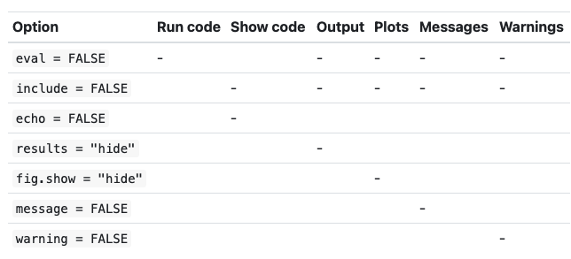

2. What are the differences between messages and warnings?

```r
message("You will not see the message.")
```

```
## You will not see the message.
```

```r
cor( c( 1 , 1 ), c( 2 , 3 ) )
```

```
## Warning in cor(c(1, 1), c(2, 3)): the standard deviation is zero
```

```
## [1] NA
```

3. Cache options
- great for loading up computationally expensive data when knitting
- based on the code chunk only and not dependencies (see example below)
- use dependson option to solve this prob

```r
rawdata <- mtcars[1:10, ]
head(rawdata)
```

```
##                    mpg cyl disp  hp drat    wt  qsec vs am gear carb
## Mazda RX4         21.0   6  160 110 3.90 2.620 16.46  0  1    4    4
## Mazda RX4 Wag     21.0   6  160 110 3.90 2.875 17.02  0  1    4    4
## Datsun 710        22.8   4  108  93 3.85 2.320 18.61  1  1    4    1
## Hornet 4 Drive    21.4   6  258 110 3.08 3.215 19.44  1  0    3    1
## Hornet Sportabout 18.7   8  360 175 3.15 3.440 17.02  0  0    3    2
## Valiant           18.1   6  225 105 2.76 3.460 20.22  1  0    3    1
```

Here processed data is cached but if rawdata file is changed, processed data will still run the dplyr pipeline for “a_very_large_file”

```r
processed_data <- rawdata %>%
  filter(cyl == 4) %>%
  mutate(sec = qsec*4)

head(processed_data)
```

```
##             mpg cyl  disp hp drat   wt  qsec vs am gear carb   sec
## Datsun 710 22.8   4 108.0 93 3.85 2.32 18.61  1  1    4    1 74.44
## Merc 240D  24.4   4 146.7 62 3.69 3.19 20.00  1  0    4    2 80.00
## Merc 230   22.8   4 140.8 95 3.92 3.15 22.90  1  0    4    2 91.60
```

4. More options There are a total of 60 options, you can check them at the link below [chunk options](https://yihui.org/knitr/options/)

### Global options

defines default for every chunk

```r
knitr::opts_chunk$set(echo = TRUE)
```

### Inline code

The data consists of 3 types of cylinders.

## YAML header

Yet Another Markdown Langauge; used to control whole report settings

### Params

- useful for re-rendering same report for different parameters
- subset of same data
- show different dataset inputs
- show GUI for knit with parameters
- add toc/ toc_float
- theme (output: rmdformats::readthedown)

[Rmd cheatsheet](https://www.rstudio.com/wp-content/uploads/2016/03/rmarkdown-cheatsheet-2.0.pdf)

## Output formats

#### How to generate output format?

- change output in YAML
- rmarkdown::render() + params
- knit dropdown

#### output options

check parameters associated with specific outputs and change it by expanding output field

```r
?rmarkdown::html_document
```

why html is a common method : easier access, ability to apply themes, simple to make “websites”

## More output formats

#### Presentations [https://rpubs.com/lyong/768323]

## formatting

format slide title with “##” or “—” to omit title

With every ddition of “#”, the heading is brought down by 1 size

### Heading

#### Heading

##### Heading

### Use - for bullet points:

- Point1
- Point2

## code chunks and output

```r
# toggle chunk options to remove display of code
plot(cars)
```

[figure not shown]

## display modes

> - “f”: full screen
> - “w”: widescreen
> - “o”: overview
> - “h”: highlight code
> - “p” presenter notes

{.notes} This is my *note*.

#### Dashboards